# Exploratory Data Analysis (EDA)

- A crucial step in the data science process, allowing you to understand the underlying structure of your data before applying any machine learning models or conducting deeper analyses. Below are the detailed techniques and steps involved in EDA:

## 1. Data Collection

- Understanding the Data Source: Know where the data comes from (e.g., databases, web scraping, APIs).
- Importing Data: Use tools like Pandas in Python to import data from various formats (CSV, Excel, JSON, etc.).
- Data Overview: Display the first few rows of the dataset using head() or sample() to get an initial understanding.

## 2. Data Cleaning

- Handling Missing Values:
  - Detection: Identify missing values using isnull() or info().
  - Imputation: Fill missing values using methods like mean, median, mode, or forward/backward filling. Alternatively, drop missing values if appropriate.
- Handling Outliers:
  - Detection: Use box plots, IQR (Interquartile Range), or Z-score to identify outliers.
  - Treatment: Remove or transform outliers, depending on the analysis requirement.

# Handling Outliers

### Step 1 : Create a Dataset

- We'll simulate a dataset of employee salaries in a company where most salaries are within a typical range, but a few outliers exist due to high executive pay or data entry errors.

```python
import pandas as pd
import numpy as np

# Set random seed for reproducibility --- ?
# A random seed is an initial value used to initialize a random number generator.
np.random.seed(42)

# Create a dataset with 1000 employees
# Most salaries will be between 40,000 and 120,000
salaries = np.random.normal(70000, 15000, 1000)

# Introduce some outliers (extremely high salaries)
salaries = np.append(salaries, [300000, 350000, 400000, 1000000])

# Create a DataFrame
df = pd.DataFrame(salaries, columns=['Salary'])

# Display the first few rows of the dataset
print(df.head())
```

```
         Salary
0  77450.712295
1  67926.035482
2  79715.328072
3  92845.447846
4  66487.699379
```

### Step 2: Detect Outliers

```python
# Calculate Q1 (25th percentile) and Q3 (75th percentile)
Q1 = df['Salary'].quantile(0.25)
Q3 = df['Salary'].quantile(0.75)
IQR = Q3 - Q1
# IQR

# Define the outlier range
lower_bound = Q1 - 1.5 * IQR
upper_bound = Q3 + 1.5 * IQR
#lower_bound
#upper_bound

# Identify outliers
outliers_iqr = df[(df['Salary'] < lower_bound) | (df['Salary'] > upper_bound)]
print("Outliers detected using IQR method:")
print(outliers_iqr)
```

```
Outliers detected using IQR method:
              Salary
74      30703.823439
179    110802.537499
209    127790.972360
262     21380.989899
478    116183.212127
646     29546.700356
668     30235.452874
755    109485.730973
1000   300000.000000
1001   350000.000000
1002   400000.000000
1003  1000000.000000
```

### Step 3: Treat Outliers

```python
# Remove outliers using the IQR method
df_cleaned = df[(df['Salary'] >= lower_bound) & (df['Salary'] <= upper_bound)]
print("Dataset after removing outliers:")
print(df_cleaned.describe())
```

```
Dataset after removing outliers:
              Salary
count     992.000000
mean    70276.059897
std     14196.074353
min     32925.332498
25%     60406.226097
50%     70379.509184
75%     79681.045112
max    108600.397049
```

```python
#Practice
# Set the seed
np.random.seed(21) #42 is famously known as "The Answer to the Ultimate Question of Life, the Universe, and Everything" from Douglas Adams' book The Hitchhiker's Guide to the Galaxy, which is why it’s often used as a fun, default seed value.

# Generate some random numbers
random_numbers = np.random.rand(5)
print(random_numbers)
```

```
[0.04872488 0.28910966 0.72096635 0.02161625 0.20592277]
```

- Handling Duplicates:
  - Detection: Use duplicated() to find duplicate rows.
  - Removal: Drop duplicates using drop_duplicates().
- Data Type Conversion:
  - Convert data types if needed, especially dates or categorical variables.
  - Use astype() for conversion.

## 3. Univariate Analysis

- Descriptive Statistics:
  - Summary of each feature (mean, median, mode, standard deviation, variance).
  - Use describe() for numerical data and value_counts() for categorical data.

#### Example of Univariate Analysis

- Let's use Python to perform univariate analysis on a dataset.
- Dataset: Simulated Heights of 1000 People

```python
import numpy as np
import pandas as pd
import matplotlib.pyplot as plt
import seaborn as sns

# Simulate a dataset of heights (in cm) with mean = 170 and standard deviation = 10
np.random.seed(42)
heights = np.random.normal(170, 10, 1000)

# Create a DataFrame
df = pd.DataFrame(heights, columns=['Height'])

# Display basic statistics
df.describe()
```

|  | Height |
| --- | --- |
| count | 1000.000000 |
| mean | 170.193321 |
| std | 9.792159 |
| min | 137.587327 |
| 25% | 163.524097 |
| 50% | 170.253006 |
| 75% | 176.479439 |
| max | 208.527315 |

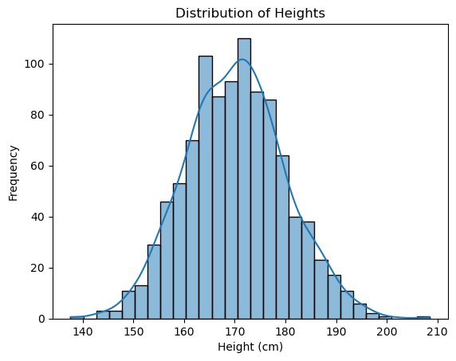

```python
# Plot the distribution of heights
sns.histplot(df['Height'], kde=True)
plt.title('Distribution of Heights')
plt.xlabel('Height (cm)')
plt.ylabel('Frequency')
plt.show()
```

```python
# Calculate and print the mean, median, and mode
mean_height = df['Height'].mean()
median_height = df['Height'].median()
mode_height = df['Height'].mode()[0]

print(f"Mean Height: {mean_height:.2f} cm")
print(f"Median Height: {median_height:.2f} cm")
print(f"Mode Height: {mode_height:.2f} cm")
```

```
Mean Height: 170.19 cm
Median Height: 170.25 cm
Mode Height: 137.59 cm
```

- Visualization:
  - Histograms: Understand the distribution of numerical data.
  - Bar Charts: Visualize categorical data.
  - Box Plots: Detect outliers and understand the distribution.

## 4. Bivariate Analysis

- Correlation Analysis:
  - Use corr() to understand relationships between numerical variables.
  - Visualize correlations using heatmaps.
- Scatter Plots:
  - Visualize the relationship between two numerical variables.
  - Helps in identifying patterns, trends, or outliers.
- Box Plots/Violin Plots:
  - Compare distributions of a numerical variable across different categories.
  - Violin plots add a density estimate to box plots.

## 5. Multivariate Analysis

- Pair Plots:
  - Visualize pairwise relationships in a dataset.
  - Useful for detecting correlations, distributions, and patterns across multiple variables.
- Heatmaps:
  - Visualize correlation matrices to understand relationships across many features.
- PCA (Principal Component Analysis):
  - Dimensionality reduction technique to identify patterns in high-dimensional data.
  - Visualize the principal components to understand variance in the data.

## 6. Feature Engineering

- Creating New Features:
  - Derive new features from existing ones, e.g., converting timestamps to day, month, year, or creating interaction terms.
- Feature Encoding:
  - Encode categorical variables using methods like one-hot encoding or label encoding.
- Feature Scaling:
  - Normalize or standardize numerical features to bring them onto the same scale.

### Step 1: Create a Dataset

We'll create a dataset of fictional movies with the following columns:

- Title: The name of the movie.
- Genre: The genre of the movie.
- Duration: The length of the movie in minutes.
- Budget: The budget of the movie in millions.
- Director: The director of the movie.
- Rating: The IMDb rating of the movie.

```python
import pandas as pd

# Create a sample dataset
data = {
    'Title': ['Movie A', 'Movie B', 'Movie C', 'Movie D', 'Movie E'],
    'Genre': ['Action', 'Comedy', 'Action', 'Drama', 'Comedy'],
    'Duration': [120, 90, 150, 110, 100],
    'Budget': [100, 50, 200, 150, 80],
    'Director': ['Director X', 'Director Y', 'Director X', 'Director Z', 'Director Y'],
    'Rating': [7.5, 6.0, 8.0, 7.0, 6.5]
}

# Convert the dictionary into a DataFrame
df = pd.DataFrame(data)

# Display the DataFrame
df
```

|  | Title | Genre | Duration | Budget | Director | Rating |
| --- | --- | --- | --- | --- | --- | --- |
| 0 | Movie A | Action | 120 | 100 | Director X | 7.5 |
| 1 | Movie B | Comedy | 90 | 50 | Director Y | 6.0 |
| 2 | Movie C | Action | 150 | 200 | Director X | 8.0 |
| 3 | Movie D | Drama | 110 | 150 | Director Z | 7.0 |
| 4 | Movie E | Comedy | 100 | 80 | Director Y | 6.5 |

### Step 2: Creating New Features

Now that we have our dataset, let’s create some new features that might be useful for analysis.

#### 1. Duration_Category: Categorizing Movies by Length

We can categorize movies into "Short," "Medium," and "Long" based on their duration

```python
# Create a new feature 'Duration_Category'
df['Duration_Category'] = pd.cut(df['Duration'],
                                 bins=[0, 100, 130, float('inf')],
                                 labels=['Short', 'Medium', 'Long'])

# Display the DataFrame with the new feature
df[['Title', 'Duration', 'Duration_Category']]
df
```

|  | Title | Genre | Duration | Budget | Director | Rating | Duration_Category |
| --- | --- | --- | --- | --- | --- | --- | --- |
| 0 | Movie A | Action | 120 | 100 | Director X | 7.5 | Medium |
| 1 | Movie B | Comedy | 90 | 50 | Director Y | 6.0 | Short |
| 2 | Movie C | Action | 150 | 200 | Director X | 8.0 | Long |
| 3 | Movie D | Drama | 110 | 150 | Director Z | 7.0 | Medium |
| 4 | Movie E | Comedy | 100 | 80 | Director Y | 6.5 | Short |

```python
import pandas as pd

# Sample data
duration_data = [120, 90, 150, 110, 100]

# Define bins
# bins = [0, 100, 130, float('inf')]

# Use pd.cut to categorize data
categories = pd.cut(data, bins=[0, 100, 130, float('inf')])

print(categories)
```

[output not shown]

We used pd.cut() to create a categorical feature, dividing the duration into three bins: Short (0-100 minutes), Medium (100-130 minutes), and Long (above 130 minutes).

#### 2. Budget_per_minute: Budget Efficiency

We can create a new feature that calculates the budget per minute of the movie.

```python
# Create a new feature 'Budget_per_minute'
df['Budget_per_minute'] = df['Budget'] / df['Duration']

# Display the DataFrame with the new feature
df[['Title', 'Budget', 'Duration', 'Budget_per_minute']]
```

|  | Title | Budget | Duration | Budget_per_minute |
| --- | --- | --- | --- | --- |
| 0 | Movie A | 100 | 120 | 0.833333 |
| 1 | Movie B | 50 | 90 | 0.555556 |
| 2 | Movie C | 200 | 150 | 1.333333 |
| 3 | Movie D | 150 | 110 | 1.363636 |
| 4 | Movie E | 80 | 100 | 0.800000 |

```python
df
```

[output not shown]

The new feature Budget_per_minute is created by dividing the budget by the duration of the movie. This gives us an idea of how much was spent per minute of the film.

### Step 3: Feature Encoding

Next, we need to convert categorical features into numerical values because most machine learning models cannot handle categorical data directly.

#### 1. One-Hot Encoding for Genre

We'll use one-hot encoding to convert the Genre column into numerical values.

```python
# Perform one-hot encoding "pd.get_dummies()" on the 'Genre' column
genre_dummies = pd.get_dummies(df['Genre'], prefix='Genre')
genre_dummies
```

[output not shown]

```python
# Concatenate the one-hot encoded columns with the original DataFrame
df = pd.concat([df, genre_dummies], axis=1)
df
```

[output not shown]

```python
# Display the DataFrame after encoding
df.drop('Genre', axis=1, inplace=True)
df
```

[output not shown]

#### 2. Label Encoding for Director

For the Director column, we’ll use label encoding to convert each director into a unique numerical value.  
Label encoding assigns a unique integer to each category. Here, each director is represented by a unique number.

```python
from sklearn.preprocessing import LabelEncoder

# Initialize the label encoder
label_encoder = LabelEncoder()

# Perform label encoding on the 'Director' column
df['Director_Encoded'] = label_encoder.fit_transform(df['Director'])

# Display the DataFrame with the encoded 'Director' feature
df[['Title', 'Director', 'Director_Encoded']]
```

[output not shown]

### Step 4: Feature Scaling

Finally, we need to scale numerical features, especially those with a wide range, to ensure that all features contribute equally to the model.

#### 1. Min-Max Scaling for Budget and Duration

We’ll scale the Budget and Duration features using Min-Max scaling.

```python
from sklearn.preprocessing import MinMaxScaler

# Initialize the MinMaxScaler
scaler = MinMaxScaler()

# Apply scaling to 'Budget' and 'Duration'
df[['Budget_Scaled', 'Duration_Scaled']] = scaler.fit_transform(df[['Budget', 'Duration']])

# Display the DataFrame after scaling
df[['Title', 'Budget', 'Budget_Scaled', 'Duration', 'Duration_Scaled']]
```

[output not shown]

Min-Max Scaling transforms the features to a fixed range, usually between 0 and 1. This ensures that all features have the same scale, preventing any single feature from dominating others.

```python
df
```

[output not shown]

## 7. Data Visualization

- Distribution Plots: Show how data is distributed using histograms, KDE plots.
- Bar Plots: Compare categorical data.
- Box Plots: Understand data spread and identify outliers.
- Heatmaps: Display the correlation between different features.
- Scatter Plots: Show the relationship between two numerical variables.
- Pair Plots: Visualize relationships across multiple variables.
- Line Plots: Use for time series data to see trends over time.

### Common plot types and how they differ:

1. Line Plot
- Use Case: To show trends over time or continuous data.
- Description: A line plot connects data points with a line, usually used to show the relationship between a continuous variable and time.
- Example: Plotting monthly sales over a year.
1. Scatter Plot
- Use Case: To visualize the relationship between two numerical variables.
- Description: Each point represents an observation; the position on the x and y axes represents its values in the two variables.
- Example: Plotting the relationship between height and weight.
1. Bar Plot
- Use Case: To compare categories or show counts.
- Description: A bar plot uses bars to represent the frequency or value of different categories.
- Example: Plotting the number of students in each grade.
1. Histogram
- Use Case: To show the distribution of a single continuous variable.
- Description: A histogram groups data into bins and shows the number of data points in each bin, visualizing the distribution.
- Example: Plotting the distribution of exam scores.
1. Box Plot (Box-and-Whisker Plot)
- Use Case: To show the distribution, median, and quartiles of a dataset, and to detect outliers.
- Description: A box plot displays the median, quartiles, and potential outliers in the data.
- Example: Comparing the distribution of salaries across different departments.
1. Heatmap
- Use Case: To show the magnitude of values across two dimensions, often with a color scale.
- Description: A heatmap uses color to represent values in a matrix, often used to show correlation matrices or frequency of occurrences.
- Example: Visualizing the correlation between multiple variables in a dataset.
1. Pie Chart
- Use Case: To show the proportion of categories in a whole.
- Description: A pie chart is a circular graph divided into slices to illustrate numerical proportions.
- Example: Plotting the market share of different companies.
1. Pair Plot
- Use Case: To visualize the pairwise relationships between multiple variables.
- Description: A pair plot creates a matrix of scatter plots for each pair of variables, often with histograms on the diagonals.
- Example: Exploring the relationships between different features in the Iris dataset.
1. Violin Plot Use Case: To show the distribution of a variable and its probability density. Description: A violin plot combines a box plot with a kernel density plot, showing the distribution, central tendency, and variability. Example: Comparing the distribution of exam scores across different classes.
2. Bubble Plot Use Case: To show the relationship between three numerical variables. Description: A bubble plot is like a scatter plot but with an additional third variable represented by the size of the points. Example: Visualizing the relationship between population, GDP, and life expectancy.
3. Density Plot Use Case: To visualize the distribution of a single continuous variable. Description: A density plot is a smoothed version of a histogram, showing the probability density of the data at different values. Example: Plotting the distribution of income levels.
4. Area Plot Use Case: To show the cumulative total over time or another continuous variable. Description: An area plot is similar to a line plot but with the area below the line filled in, often used to show part-to-whole relationships. Example: Plotting cumulative sales over a year.
5. Radar Chart (Spider Plot) Use Case: To compare multiple variables for different categories. Description: A radar chart is a web-like plot that displays multiple variables for one or more categories. Example: Comparing the performance of different players across various metrics.
6. 3D Plot Use Case: To visualize the relationship between three variables. Description: A 3D plot shows data points in three-dimensional space, useful for visualizing complex relationships. Example: Plotting the relationship between age, income, and expenditure.

Summary

- Line Plots and Area Plots are best for showing trends over time.
- Scatter Plots, Bubble Plots, and 3D Plots are ideal for exploring relationships between variables.
- Bar Plots and Pie Charts are commonly used for comparing categories.
- Histograms, Box Plots, and Violin Plots are effective for showing distributions.
- Heatmaps and Correlation Matrices are useful for understanding relationships and interactions across multiple variables.
- Pair Plots and Radar Charts help in comparing multiple features or categories simultaneously.

## 8. Summarization and Reporting

- Summary Statistics: Present key insights from the data.
- Visualizations: Include relevant plots and charts to support findings.
- Key Insights: Highlight patterns, trends, and potential areas of interest for further analysis or modeling.
- Recommendations: Based on the analysis, suggest the next steps or hypotheses for testing.

```python
import pandas as pd
df = pd.read_json("FIle Name/Path")
df = pd.read_csv("FIle Name/Path")
```

```python
import numpy as np # linear algebra
import pandas as pd # data processing, CSV file I/O (e.g. pd.read_csv)


import matplotlib.pyplot as plt
import seaborn as sns
import squarify
from collections import Counter
import warnings
from wordcloud import WordCloud
warnings.filterwarnings("ignore", category=FutureWarning)
import plotly.express as px
import networkx as nx
import joypy
import plotly.graph_objs as go
```

```python
df = pd.read_csv("IMdB_India_Top250.csv")

df.head
#(), df.info()
```

```python
cleaned_df=df

cleaned_df.head()
```

[output not shown]

# Visualising Dataset

```python
plt.figure(figsize=(12, 6))
df['Year of release'].value_counts().sort_index().plot(kind='bar', color='skyblue')
plt.title('Distribution of Movies by Release Year')
plt.xlabel('Year of Release')
plt.ylabel('Number of Movies')
plt.show()
```

[output not shown]

```python
genres = df['Genre'].str.split(',', expand=True).stack().str.strip().value_counts()

plt.figure(figsize=(12, 8))
genres.plot(kind='barh', color='lightcoral')
plt.title('Distribution of Movies by Genre')
plt.xlabel('Number of Movies')
plt.ylabel('Genre')
plt.show()
```

[output not shown]

```python
top_directors = df['Director'].value_counts().head(10)

plt.figure(figsize=(10, 6))
top_directors.plot(kind='bar', color='seagreen')
plt.title('Top 10 Directors by Number of Movies')
plt.xlabel('Director')
plt.ylabel('Number of Movies')
plt.xticks(rotation=45)
plt.show()
```

[output not shown]

```python
plt.figure(figsize=(10, 6))
df['Rating'].hist(bins=20, color='mediumpurple')
plt.title('Distribution of Movie Ratings')
plt.xlabel('Rating')
plt.ylabel('Number of Movies')
plt.show()
```

[output not shown]

```python
df['Year of release'] = df['Year of release'].astype(int)
df['Genre'] = df['Genre'].apply(lambda x: x.split(',')[0])

pivot_data = df.pivot_table(index='Genre', columns='Year of release', values='Rating', aggfunc='mean')

plt.figure(figsize=(16, 10))
sns.heatmap(pivot_data, cmap='coolwarm', annot=True, fmt=".2f", linewidths=.5)
plt.title('Heatmap of Average Movie Ratings by Year and Genre', fontsize=16)
plt.xlabel('Year of Release')
plt.ylabel('Genre')
plt.show()
```

[output not shown]

```python
df['Year of release'] = df['Year of release'].astype(str)

fig = px.sunburst(df, path=['Genre', 'Director', 'Year of release'], values='Rating',
                  color='Rating', hover_data=['Rating'],
                  color_continuous_scale='RdBu',
                  title='Sunburst of Movie Counts by Genre, Director, and Year')
fig.update_layout(margin=dict(t=50, l=25, r=25, b=25))
fig.show()
```

[output not shown]

```python
plt.figure(figsize=(14, 8))
sns.boxplot(data=df, x='Film Industry', y='Rating', palette='Set3')
plt.title('Box Plot of Movie Ratings by Film Industry', fontsize=16)
plt.xlabel('Film Industry')
plt.ylabel('Rating')
plt.xticks(rotation=45)
plt.grid(True, linestyle='--', alpha=0.7)
plt.show()
```

[output not shown]

```python
top_directors = df['Director'].value_counts().head(10).index
filtered_df = df[df['Director'].isin(top_directors)]

G = nx.Graph()

for _, row in filtered_df.iterrows():
    G.add_node(row['Movie name'], type='movie', rating=row['Rating'])
    G.add_node(row['Director'], type='director')
    G.add_edge(row['Director'], row['Movie name'], weight=row['Rating'])

pos = nx.spring_layout(G, k=0.5, seed=42)
plt.figure(figsize=(14, 14))

nx.draw(G, pos, with_labels=True, node_size=5000, node_color='skyblue', edge_color='gray', font_size=10, font_weight='bold')
movie_nodes = [node for node, attr in G.nodes(data=True) if attr['type'] == 'movie']
nx.draw_networkx_nodes(G, pos, nodelist=movie_nodes, node_color='lightgreen')

plt.title('Network Graph of Top Directors and Their Movies', fontsize=16)
plt.show()
```

[output not shown]

```python
df['Genre'] = df['Genre'].apply(lambda x: x.split(',')[0])

plt.figure(figsize=(14, 10))
joypy.joyplot(df, by='Genre', column='Rating', colormap=plt.cm.Spectral, figsize=(14,10),
              title='Ridgeline Plot of Ratings Distribution by Genre')
plt.xlabel('Rating')
plt.show()
```

[output not shown]

```python
correlation_data = df[['Rating', 'Year of release', 'User reviews']].corr()

plt.figure(figsize=(8, 6))
sns.heatmap(correlation_data, annot=True, cmap='YlGnBu', linewidths=0.5)
plt.title('Correlation Matrix of Key Attributes', fontsize=16)
plt.show()
```

[output not shown]

```python
fig = go.Figure(data=[go.Scatter3d(
    x=df['Year of release'],
    y=df['Rating'],
    z=df['User reviews'],
    mode='markers',
    marker=dict(
        size=5,
        color=df['Rating'],
        colorscale='Viridis',
        opacity=0.8
    )
)])

fig.update_layout(scene=dict(
    xaxis_title='Year of Release',
    yaxis_title='Rating',
    zaxis_title='User Reviews'),
    title='3D Scatter Plot of Ratings, Year of Release, and User Reviews'
)
fig.show()
```

[output not shown]

```python
text = ' '.join(df['Description'].tolist())
wordcloud = WordCloud(width=800, height=400, background_color='white', colormap='inferno').generate(text)

plt.figure(figsize=(10, 6))
plt.imshow(wordcloud, interpolation='bilinear')
plt.axis('off')
plt.title('Word Cloud of Movie Descriptions', fontsize=16)
plt.show()
```

[output not shown]

```python
fig = px.treemap(df, path=['Genre', 'Movie name'], values='Rating',
                 color='Rating', hover_data=['Director'],
                 color_continuous_scale='RdBu',
                 title='Treemap of Movies by Genre and Rating')
fig.update_layout(margin=dict(t=50, l=25, r=25, b=25))
fig.show()
```

[output not shown]

```python
top_20_movies = df.sort_values('Box office collection', ascending=False).head(20)
top_20_movies = top_20_movies[::-1]

fig, ax = plt.subplots(figsize=(10, 8))
ax.hlines(y=top_20_movies['Movie name'], xmin=0, xmax=top_20_movies['Box office collection'], color='skyblue')
ax.plot(top_20_movies['Box office collection'], top_20_movies['Movie name'], 'o', markersize=8, color='blue')
ax.set_title('Top 20 Movies by Box Office Collection', fontsize=16)
ax.set_xlabel('Box Office Collection ($)')
ax.set_ylabel('Movie Name')
plt.show()
```

[output not shown]

```python
average_ratings = df.groupby('Genre')['Rating'].mean().sort_values()
categories = average_ratings.index.tolist()
ratings = average_ratings.values

angles = np.linspace(0, 2 * np.pi, len(categories), endpoint=False).tolist()
ratings = np.concatenate((ratings,[ratings[0]]))
angles += angles[:1]

fig, ax = plt.subplots(figsize=(8, 8), subplot_kw=dict(polar=True))
ax.fill(angles, ratings, color='green', alpha=0.25)
ax.plot(angles, ratings, color='green', linewidth=2)
ax.set_yticklabels([])
ax.set_xticks(angles[:-1])
ax.set_xticklabels(categories, fontsize=12)
ax.set_title('Polar Area Chart of Average Ratings by Genre', fontsize=16)
plt.show()
```

[output not shown]

```python
df['User reviews (binned)'] = pd.cut(df['User reviews'], bins=[0, 50, 100, 500, 1000, 2000],
                                     labels=['0-50', '51-100', '101-500', '501-1000', '1001-2000'])

plt.figure(figsize=(14, 8))
sns.barplot(data=df, x='Film Industry', y='Rating', hue='User reviews (binned)', palette='Set2')
plt.title('Grouped Bar Chart of Ratings vs. Binned User Reviews by Film Industry', fontsize=16)
plt.xlabel('Film Industry')
plt.ylabel('Rating')
plt.xticks(rotation=45)
plt.legend(title='User reviews (binned)')
plt.show()
```

[output not shown]

```python
from datetime import datetime
```

```python
datetime
```

```
datetime.datetime
```